# 游戏相关岗位招聘和薪酬（lp）

## 总述

本次有效数据1002条（城市发布量>=90）,主要分析游戏相关岗位招聘和薪酬，我们将从如下方面分析：

## 01.城市分布

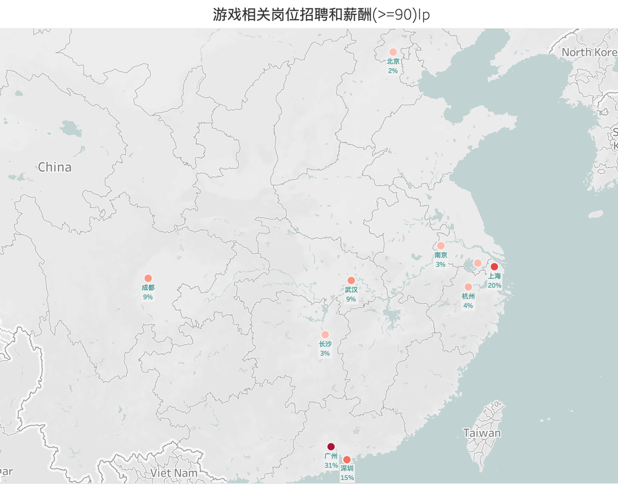

## 02.行业分布

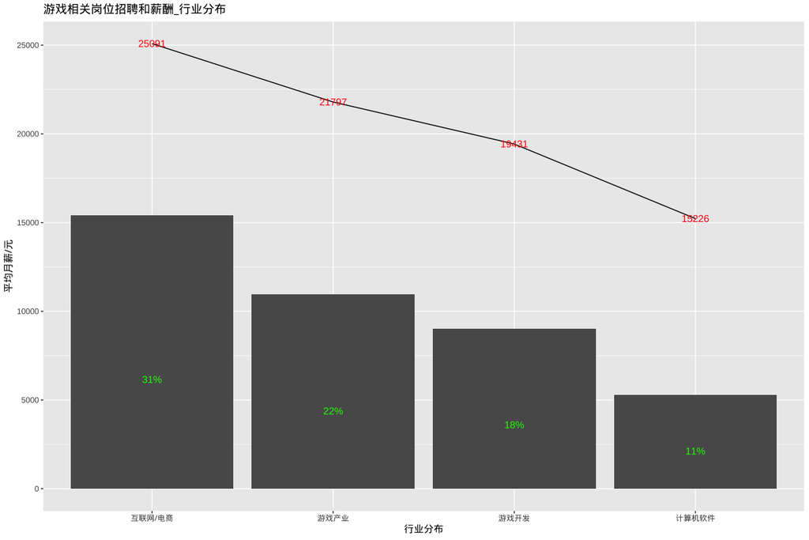

## 03.企业规模

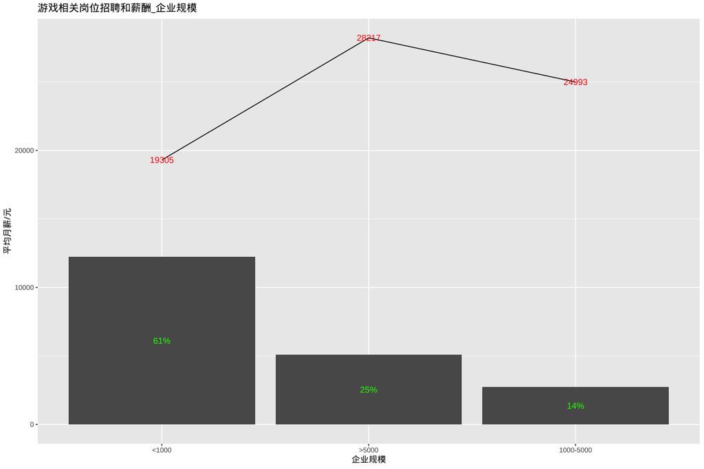

## 04.工作经验

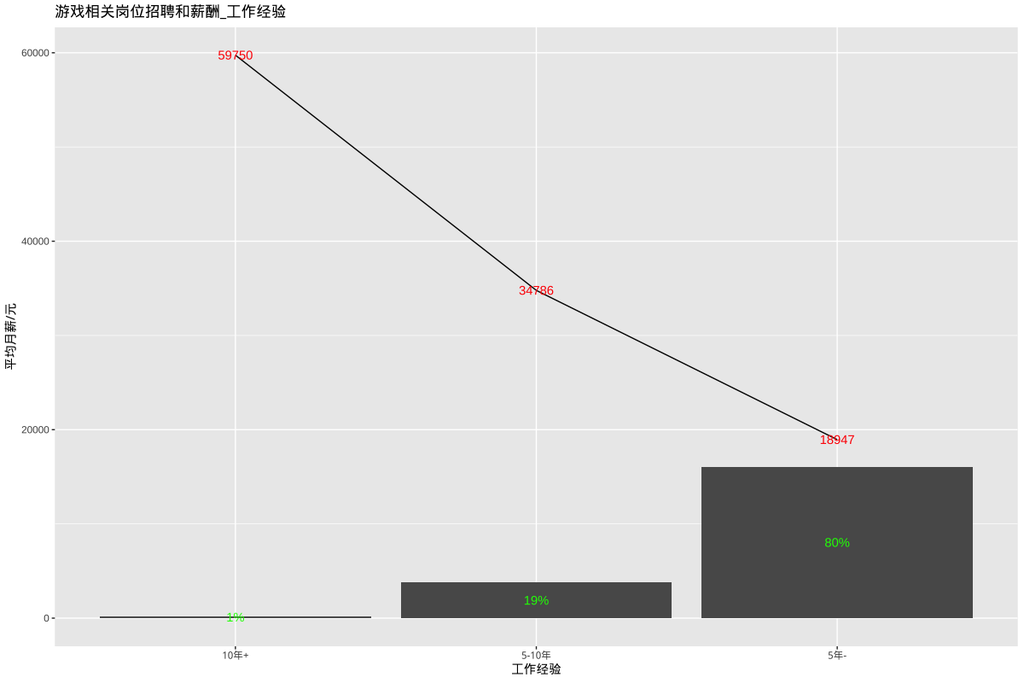

## 05.学历要求

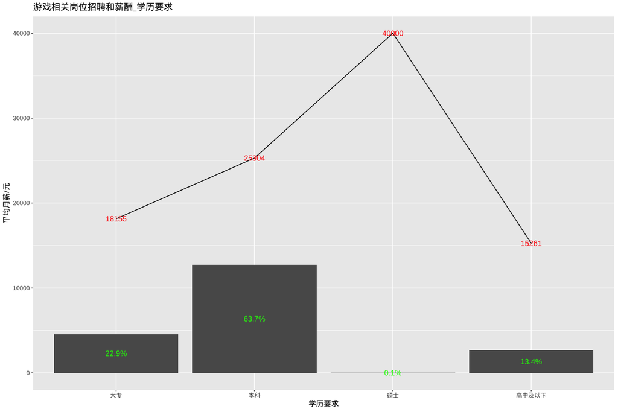

## 06.岗位细分

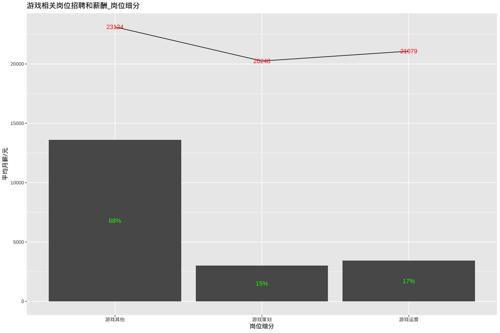